# Monitoria 3

Julián Soto

2024-02-24

**Descripción del experimento**

Suponer que se lanza al aire una moneda balanceada. El interés de este ejercicio es estimar la probabilidad de caer cara. Se utiliza el software R para simular los lanzamientos de la moneda usando la función rbinom(n, size=1,prob=0.5). Usar la siguiente notación: C=caer cara, fn(C) es la frecuencia relativa de caer cara, P(C) la probabilidad de caer cara.

1. Simular el lanzamiento de una moneda balanceada n=5 veces y calcular la frecuencia relativa de caer cara.

   ```r
   #Supongamos que caer Cara es 1

   set.seed(111)

   experimento <- rbinom(5, size=1,prob=0.5)


   print(experimento)
   ```

   ```
   ## [1] 1 1 0 1 0
   ```

   ```r
   f_n_1 <- sum(experimento)/5
   print(f_n_1)
   ```

   ```
   ## [1] 0.6
   ```

2. Simular el lanzamiento de una moneda 20 veces y calcular la frecuencia relativa de caer cara.

   ```r
   set.seed(111)

   experimento <- rbinom(20, size=1,prob=0.5)


   print(experimento)
   ```

   ```
   ##  [1] 1 1 0 1 0 0 0 1 0 0 1 1 0 0 0 0 0 1 0 1
   ```

   ```r
   f_n_1 <- sum(experimento)/20
   print(f_n_1)
   ```

   ```
   ## [1] 0.4
   ```

3. Simular 100 veces que la moneda balanceada se lanza n=5 veces. Luego:

   ```r
   set.seed(105)

   muestras <- replicate(100, rbinom(5, size=1,prob=0.5))
   ```

   1. Calcular la frecuencia relativa de caer cara por cada uno de las 100 simulaciones. Debes tener 100 valores de frecuencias relativas de caer cara.

   ```r
   f_n <- c()

   for (i in 1:100){
     f_n <- c(f_n,sum(muestras[,i])/5)
   }
   ```

   2. Construir un gráfico de dispersión donde en el eje Y ubiques los resultados de las frecuencias relativas de caer cara y en el eje X los valores de 1 a 100 (indexación por cada simulación de los n=5 lanzamientos de la moneda).

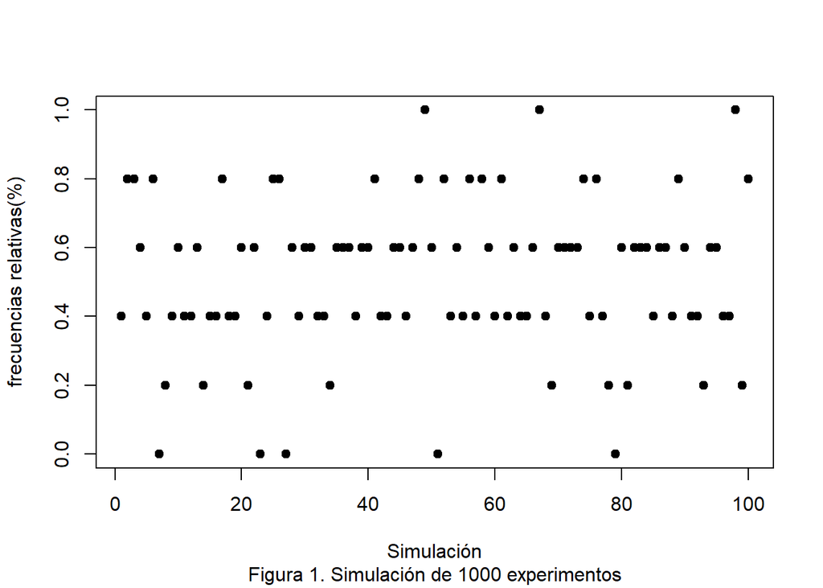

   3. Trazar una línea paralela al eje X que corte en el eje Y en el valor de la probabilidad P(C).

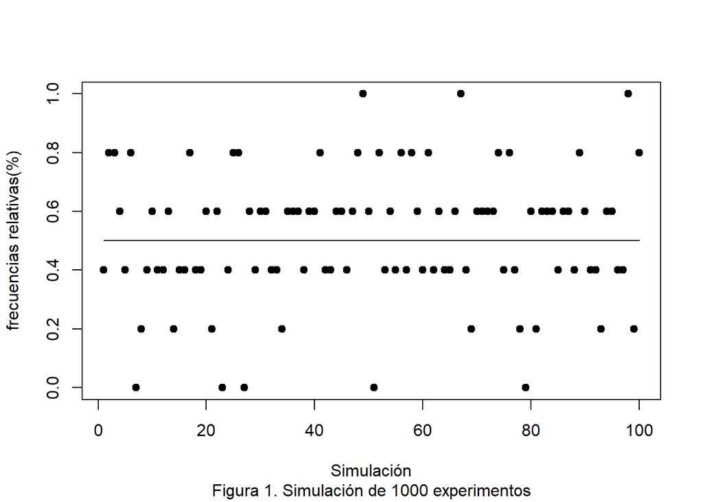

     lines(1:100,
           rep(1/2,100))
   ```

   4. Interpretar el gráfico de dispersión comparando los resultados experimentales f<sub>n</sub>(C) y el teórico P(C).

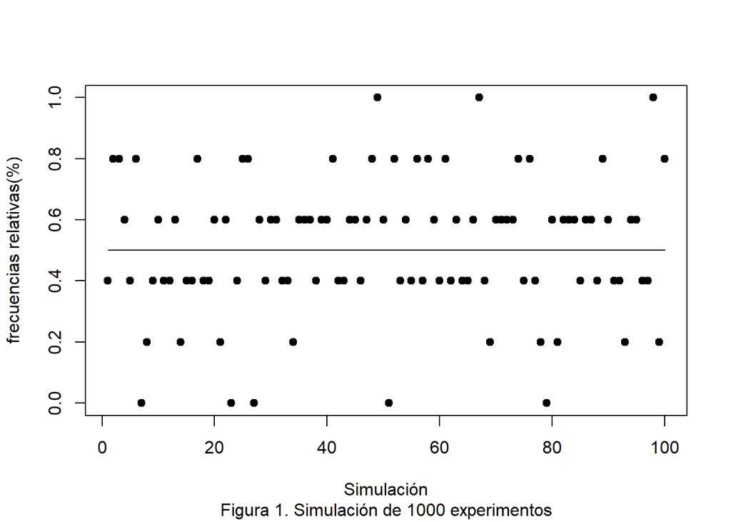

   ```r
     set.seed(105)

     muestras <- replicate(100, rbinom(5, size=1,prob=0.5))

     f_n <- c()

     for (i in 1:100){
       f_n <- c(f_n,sum(muestras[,i])/5)
     }

     lines(1:100,
           rep(1/2,100))
   ```

4. Repetir el ejercicio 3 usando n=10.

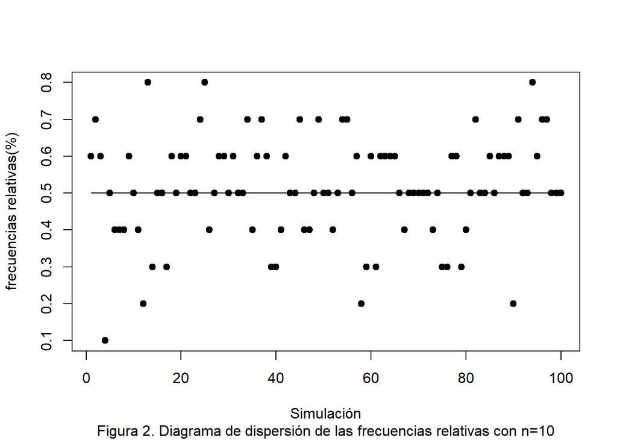

   ```r
   set.seed(105)
   n<-10

   muestras <- replicate(100, rbinom(n, size=1,prob=0.5))

   f_n <- c()

   for (i in 1:100){
     f_n <- c(f_n,sum(muestras[,i])/n)
   }

   plot(1:100,
      f_n,pch=19,
      ylab="frecuencias relativas(%)",
      xlab ="Simulación",
      #ylim= c(0,1),
      sub="Figura 2. Diagrama de dispersión de las frecuencias relativas con n=10")

   lines(1:100,
         rep(1/2,100))
   ```

5. Repetir el ejercicio 3 usando n=20.

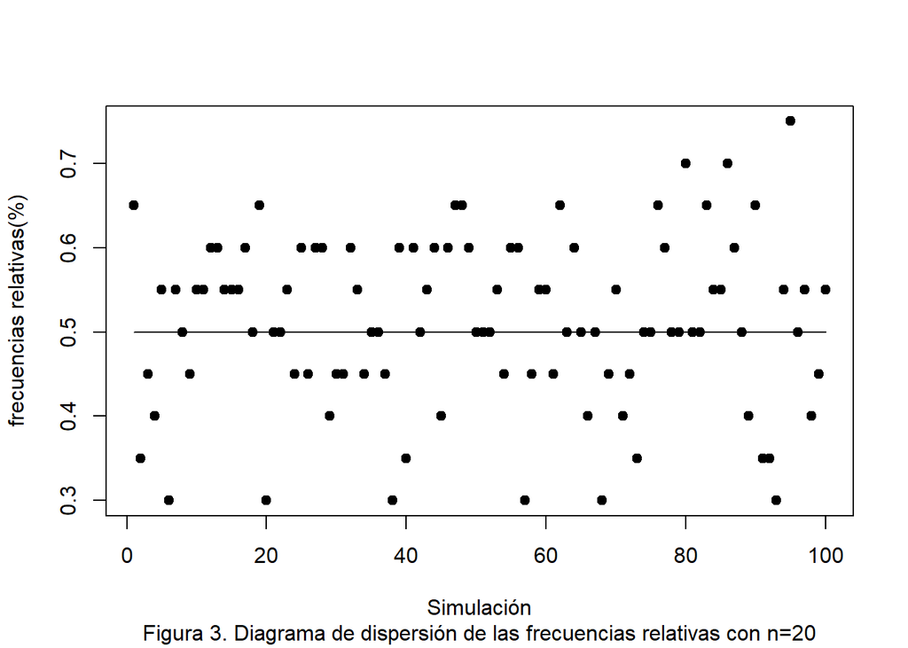

   ```r
   set.seed(105)
   n<-20

   muestras <- replicate(100, rbinom(n, size=1,prob=0.5))

   f_n <- c()

   for (i in 1:100){
     f_n <- c(f_n,sum(muestras[,i])/n)
   }

   plot(1:100,
      f_n,pch=19,
      ylab="frecuencias relativas(%)",
      xlab ="Simulación",
      #ylim= c(0,1),
      sub="Figura 3. Diagrama de dispersión de las frecuencias relativas con n=20")

   lines(1:100,
         rep(1/2,100))
   ```

6. Repetir el ejercicio 3 usando n=30.

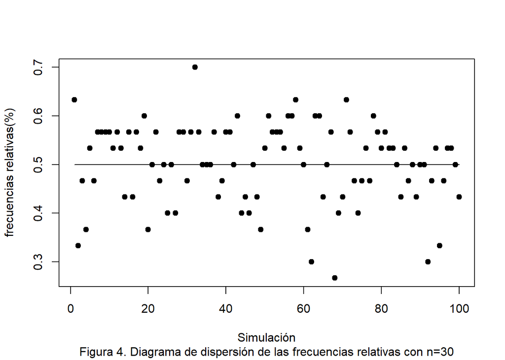

   ```r
   set.seed(105)
   n<-30

   muestras <- replicate(100, rbinom(n, size=1,prob=0.5))

   f_n <- c()

   for (i in 1:100){
     f_n <- c(f_n,sum(muestras[,i])/n)
   }

   plot(1:100,
      f_n,pch=19,
      ylab="frecuencias relativas(%)",
      xlab ="Simulación",
      #ylim= c(0,1),
      sub="Figura 4. Diagrama de dispersión de las frecuencias relativas con n=30")

   lines(1:100,
         rep(1/2,100))
   ```

7. Repetir el ejercicio 3 usando n=40.

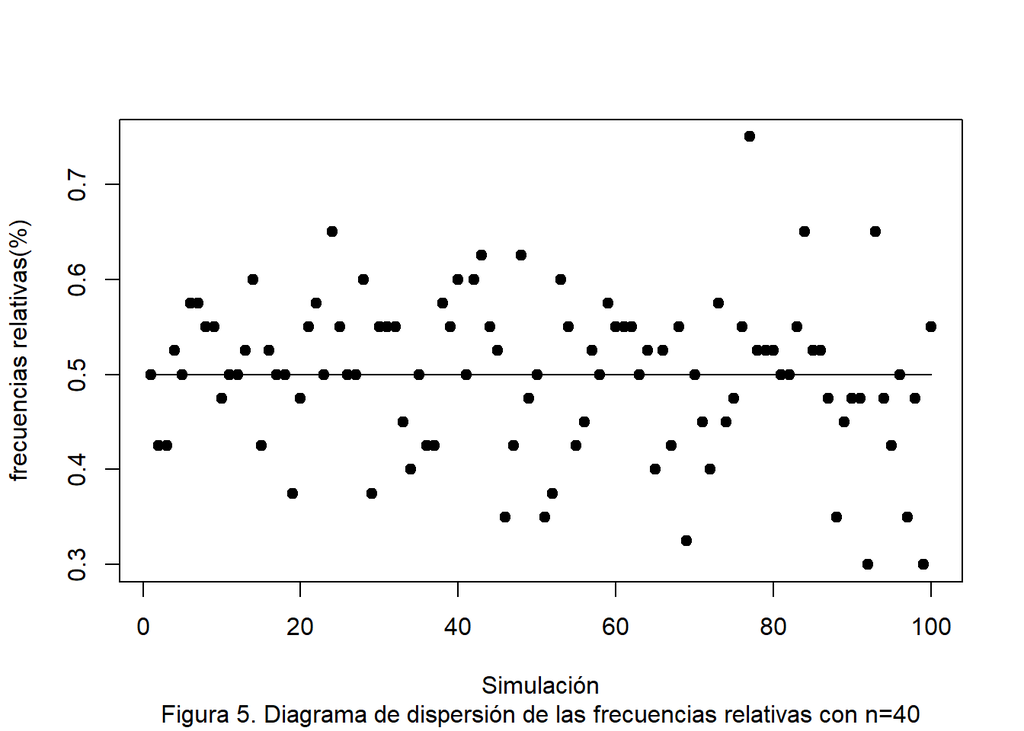

   ```r
   set.seed(105)
   n<-40

   muestras <- replicate(100, rbinom(n, size=1,prob=0.5))

   f_n <- c()

   for (i in 1:100){
     f_n <- c(f_n,sum(muestras[,i])/n)
   }

   plot(1:100,
      f_n,pch=19,
      ylab="frecuencias relativas(%)",
      xlab ="Simulación",
      #ylim= c(0,1),
      sub="Figura 5. Diagrama de dispersión de las frecuencias relativas con n=40")

   lines(1:100,
         rep(1/2,100))
   ```

8. Repetir el ejercicio 3 usando n=50.

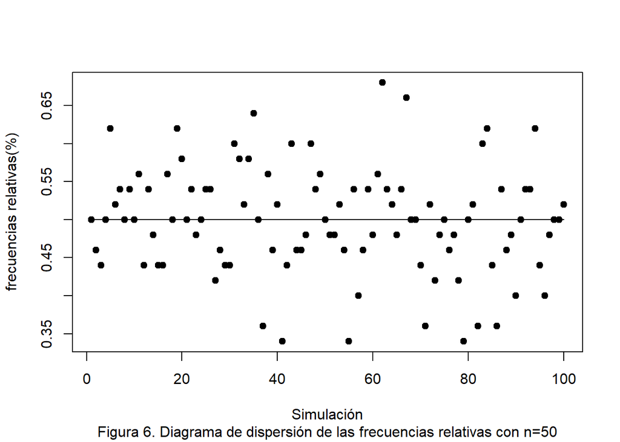

   ```r
   set.seed(105)
   n<-50

   muestras <- replicate(100, rbinom(n, size=1,prob=0.5))

   f_n <- c()

   for (i in 1:100){
     f_n <- c(f_n,sum(muestras[,i])/n)
   }

   plot(1:100,
      f_n,pch=19,
      ylab="frecuencias relativas(%)",
      xlab ="Simulación",
      #ylim= c(0,1),
      sub="Figura 6. Diagrama de dispersión de las frecuencias relativas con n=50")

   lines(1:100,
         rep(1/2,100))
   ```

9. Repetir el ejercicio 3 usando n=80.

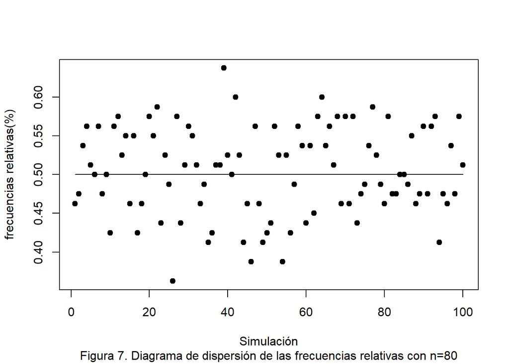

   ```r
   set.seed(105)
   n<-80

   muestras <- replicate(100, rbinom(n, size=1,prob=0.5))

   f_n <- c()

   for (i in 1:100){
     f_n <- c(f_n,sum(muestras[,i])/n)
   }

   plot(1:100,
      f_n,pch=19,
      ylab="frecuencias relativas(%)",
      xlab ="Simulación",
      #ylim= c(0,1),
      sub="Figura 7. Diagrama de dispersión de las frecuencias relativas con n=80")

   lines(1:100,
         rep(1/2,100))
   ```

10. Repetir el ejercicio 3 usando n=150.

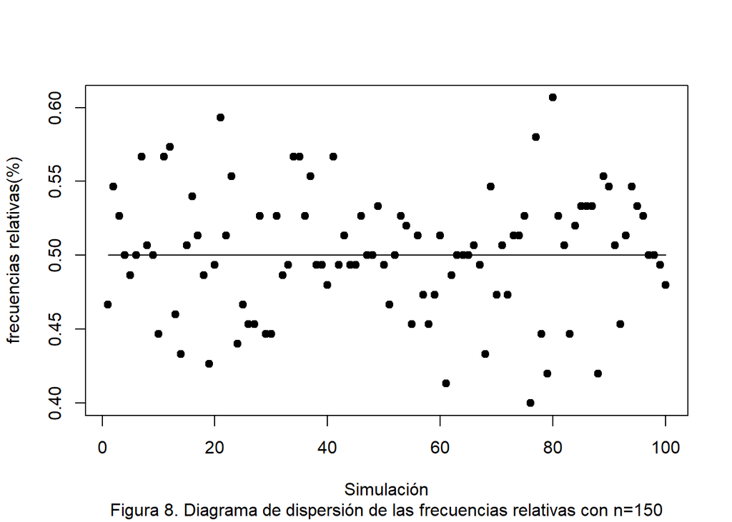

    ```r
    set.seed(105)
    n<-150

    muestras <- replicate(100, rbinom(n, size=1,prob=0.5))

    f_n <- c()

    for (i in 1:100){
      f_n <- c(f_n,sum(muestras[,i])/n)
    }

    plot(1:100,
       f_n,pch=19,
       ylab="frecuencias relativas(%)",
       xlab ="Simulación",
       #ylim= c(0,1),
       sub="Figura 8. Diagrama de dispersión de las frecuencias relativas con n=150")

    lines(1:100,
          rep(1/2,100))
    ```

11. Repetir el ejercicio 3 usando n=200.

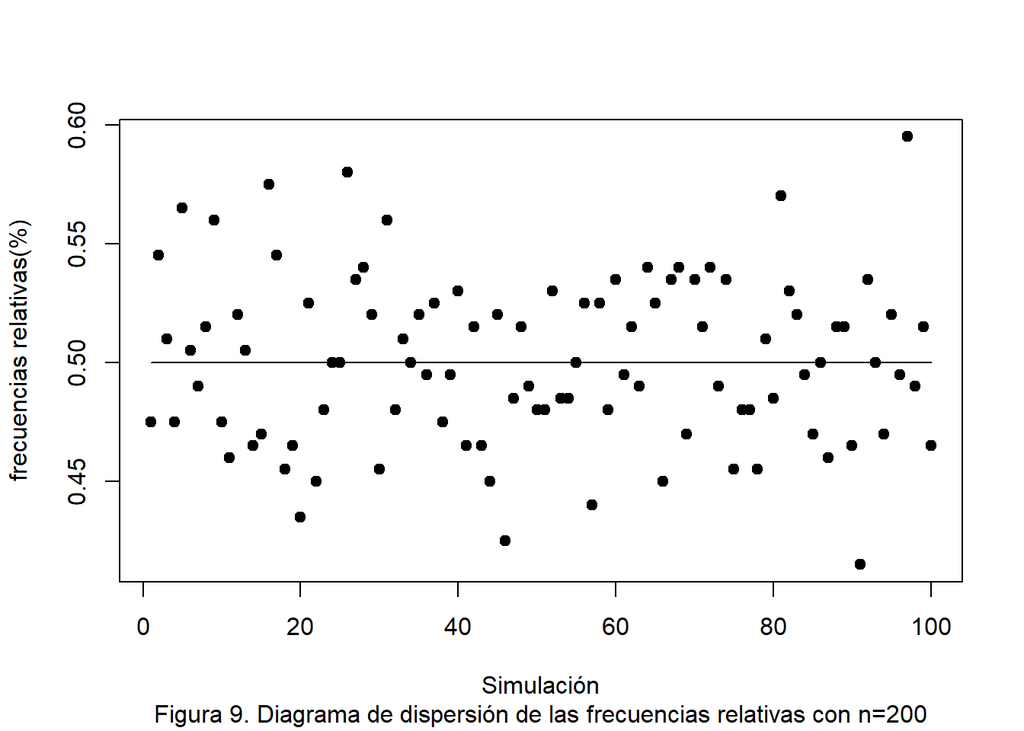

    ```r
    set.seed(105)
    n<-200

    muestras <- replicate(100, rbinom(n, size=1,prob=0.5))

    f_n <- c()

    for (i in 1:100){
      f_n <- c(f_n,sum(muestras[,i])/n)
    }

    plot(1:100,
       f_n,pch=19,
       ylab="frecuencias relativas(%)",
       xlab ="Simulación",
       #ylim= c(0,1),
       sub="Figura 9. Diagrama de dispersión de las frecuencias relativas con n=200")

    lines(1:100,
          rep(1/2,100))
    ```

12. Repetir el ejercicio 3 usando n=400.

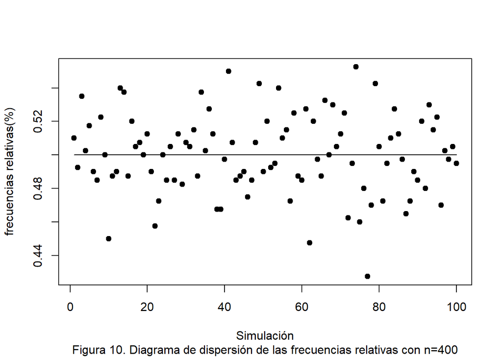

    ```r
    set.seed(105)
    n<-400

    muestras <- replicate(100, rbinom(n, size=1,prob=0.5))

    f_n <- c()

    for (i in 1:100){
      f_n <- c(f_n,sum(muestras[,i])/n)
    }

    plot(1:100,
       f_n,pch=19,
       ylab="frecuencias relativas(%)",
       xlab ="Simulación",
       #ylim= c(0,1),
       sub="Figura 10. Diagrama de dispersión de las frecuencias relativas con n=400")

    lines(1:100,
          rep(1/2,100))
    ```

13. Repetir el ejercicio 3 usando n=500.

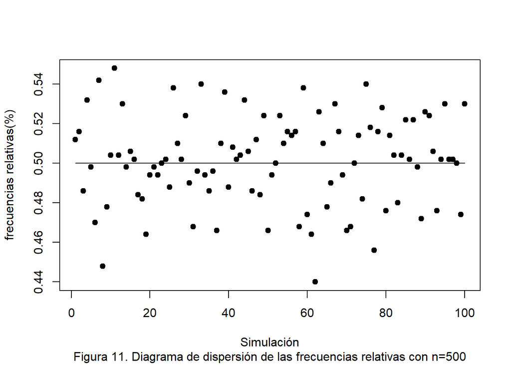

    ```r
    set.seed(105)
    n<-500

    muestras <- replicate(100, rbinom(n, size=1,prob=0.5))

    f_n <- c()

    for (i in 1:100){
      f_n <- c(f_n,sum(muestras[,i])/n)
    }

    plot(1:100,
       f_n,pch=19,
       ylab="frecuencias relativas(%)",
       xlab ="Simulación",
       #ylim= c(0,1),
       sub="Figura 11. Diagrama de dispersión de las frecuencias relativas con n=500")

    lines(1:100,
          rep(1/2,100))
    ```

14. Repetir el ejercicio 3 usando n=600.

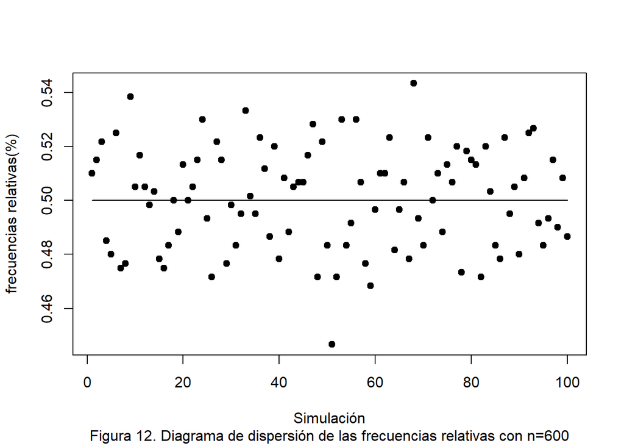

    ```r
    set.seed(105)
    n<-600

    muestras <- replicate(100, rbinom(n, size=1,prob=0.5))

    f_n <- c()

    for (i in 1:100){
      f_n <- c(f_n,sum(muestras[,i])/n)
    }

    plot(1:100,
       f_n,pch=19,
       ylab="frecuencias relativas(%)",
       xlab ="Simulación",
       #ylim= c(0,1),
       sub="Figura 12. Diagrama de dispersión de las frecuencias relativas con n=600")

    lines(1:100,
          rep(1/2,100))
    ```

15. Repetir el ejercicio 3 usando n=700.

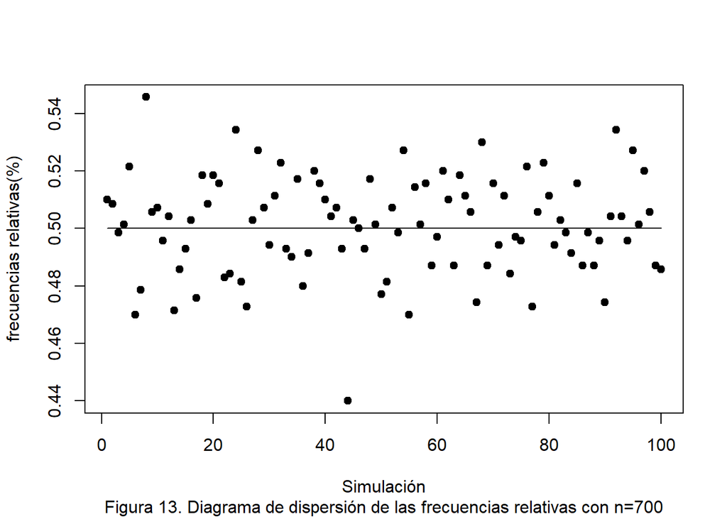

    ```r
    set.seed(105)
    n<-700

    muestras <- replicate(100, rbinom(n, size=1,prob=0.5))

    f_n <- c()

    for (i in 1:100){
      f_n <- c(f_n,sum(muestras[,i])/n)
    }

    plot(1:100,
       f_n,pch=19,
       ylab="frecuencias relativas(%)",
       xlab ="Simulación",
       #ylim= c(0,1),
       sub="Figura 13. Diagrama de dispersión de las frecuencias relativas con n=700")

    lines(1:100,
          rep(1/2,100))
    ```

16. Repetir el ejercicio 3 usando n=800.

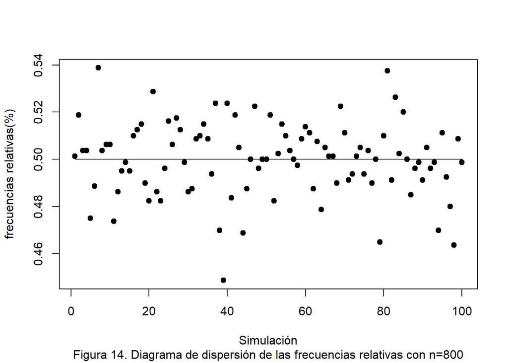

    ```r
    set.seed(105)
    n<-800

    muestras <- replicate(100, rbinom(n, size=1,prob=0.5))

    f_n <- c()

    for (i in 1:100){
      f_n <- c(f_n,sum(muestras[,i])/n)
    }

    plot(1:100,
       f_n,pch=19,
       ylab="frecuencias relativas(%)",
       xlab ="Simulación",
       #ylim= c(0,1),
       sub="Figura 14. Diagrama de dispersión de las frecuencias relativas con n=800")

    lines(1:100,
          rep(1/2,100))
    ```

17. Repetir el ejercicio 3 usando n=900.

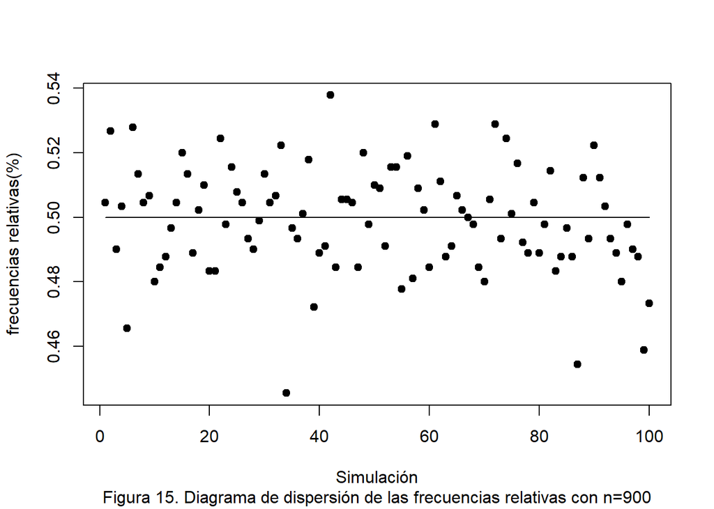

    ```r
      set.seed(105)
      n<-900

      muestras <- replicate(100, rbinom(n, size=1,prob=0.5))

      f_n <- c()

      for (i in 1:100){
    f_n <- c(f_n,sum(muestras[,i])/n)
      }

      plot(1:100,
     f_n,pch=19,
     ylab="frecuencias relativas(%)",
     xlab ="Simulación",
     #ylim= c(0,1),
     sub="Figura 15. Diagrama de dispersión de las frecuencias relativas con n=900")

      lines(1:100,
        rep(1/2,100))
    ```

18. Repetir el ejercicio 3 usando n=1000.

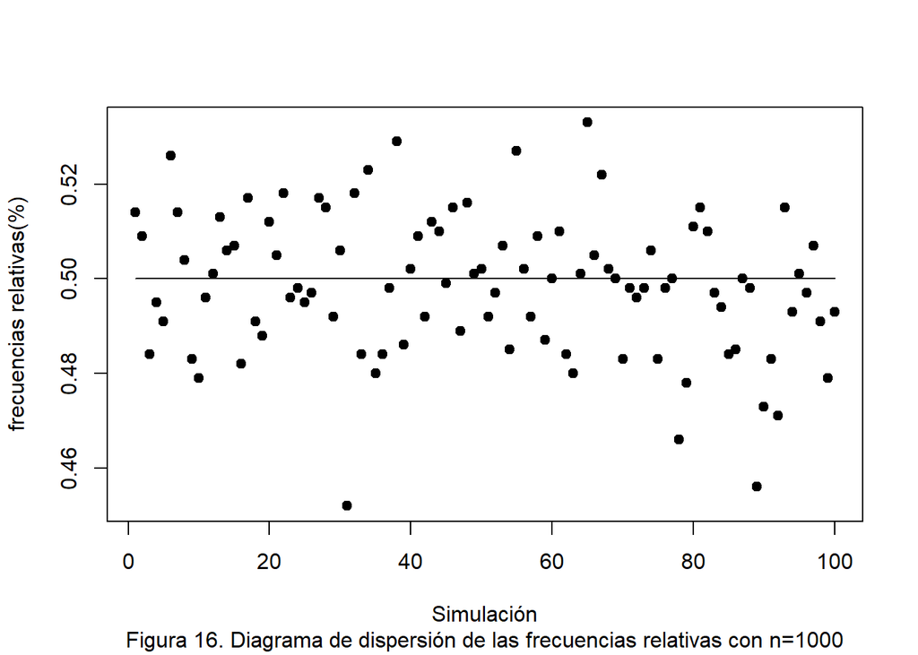

```r
set.seed(105)
n<-1000

muestras <- replicate(100, rbinom(n, size=1,prob=0.5))

f_n <- c()

for (i in 1:100){
  f_n <- c(f_n,sum(muestras[,i])/n)
}

plot(1:100,
   f_n,pch=19,
   ylab="frecuencias relativas(%)",
   xlab ="Simulación",
   #ylim= c(0,1),
   sub="Figura 16. Diagrama de dispersión de las frecuencias relativas con n=1000")

lines(1:100,
      rep(1/2,100))
```

19. Repetir el ejercicio 3 usando n=2000.

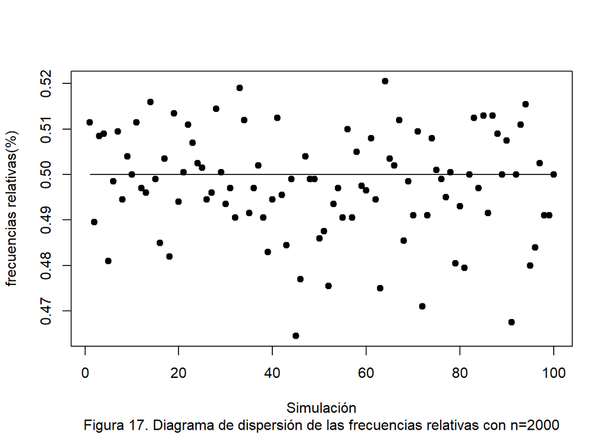

```r
set.seed(105)
n<-2000

muestras <- replicate(100, rbinom(n, size=1,prob=0.5))

f_n <- c()

for (i in 1:100){
  f_n <- c(f_n,sum(muestras[,i])/n)
}

plot(1:100,
   f_n,pch=19,
   ylab="frecuencias relativas(%)",
   xlab ="Simulación",
   #ylim= c(0,1),
   sub="Figura 17. Diagrama de dispersión de las frecuencias relativas con n=2000")

lines(1:100,
      rep(1/2,100))
```

20. Repetir el ejercicio 3 usando n=3000.

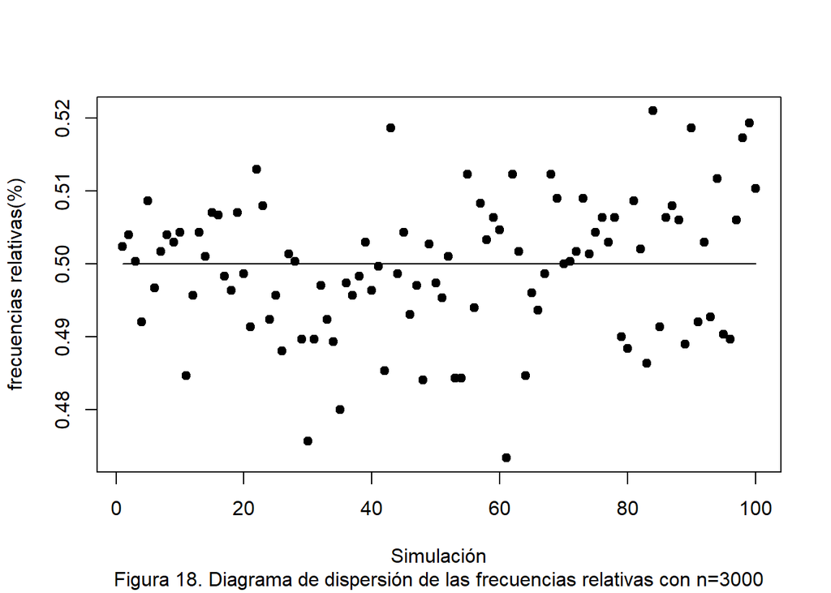

```r
set.seed(105)
n<-3000

muestras <- replicate(100, rbinom(n, size=1,prob=0.5))

f_n <- c()

for (i in 1:100){
  f_n <- c(f_n,sum(muestras[,i])/n)
}

plot(1:100,
   f_n,pch=19,
   ylab="frecuencias relativas(%)",
   xlab ="Simulación",
   #ylim= c(0,1),
   sub="Figura 18. Diagrama de dispersión de las frecuencias relativas con n=3000")

lines(1:100,
      rep(1/2,100))
```

21. Repetir el ejercicio 3 usando n=5000.

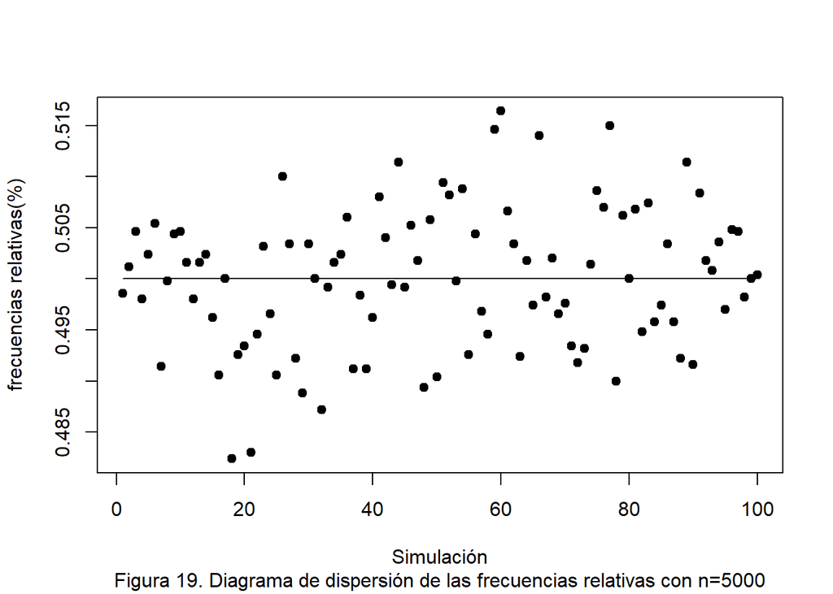

```r
set.seed(105)
n<-5000

muestras <- replicate(100, rbinom(n, size=1,prob=0.5))

f_n <- c()

for (i in 1:100){
  f_n <- c(f_n,sum(muestras[,i])/n)
}

plot(1:100,
   f_n,pch=19,
   ylab="frecuencias relativas(%)",
   xlab ="Simulación",
   #ylim= c(0,1),
   sub="Figura 19. Diagrama de dispersión de las frecuencias relativas con n=5000")

lines(1:100,
      rep(1/2,100))
```

22. Repetir el ejercicio 3 usando n=10000

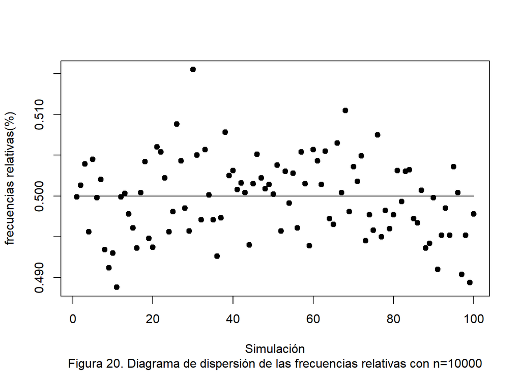

```r
set.seed(105)
n<-10000

muestras <- replicate(100, rbinom(n, size=1,prob=0.5))

f_n <- c()

for (i in 1:100){
  f_n <- c(f_n,sum(muestras[,i])/n)
}

plot(1:100,
   f_n,pch=19,
   ylab="frecuencias relativas(%)",
   xlab ="Simulación",
   #ylim= c(0,1),
   sub="Figura 20. Diagrama de dispersión de las frecuencias relativas con n=10000")

lines(1:100,
      rep(1/2,100))
```

23. Comparar los gráficos del punto 3 al 22.
24. Simular que una moneda balanceada fue lanzada n veces, n=2, 5, 10, 20, 30, 40, 50, 60, 70, 80, 90, 100, 200, 300, 400, 500, 600, 700, 800, 900, 1000, 2000, 3000, 4000, 5000, 6000, 7000, 8000, 9000 y 10000. Para estas simulaciones:
    1. Por cada valor de n calcular f<sub>n</sub>(C).

    ```r
    set.seed(105)
    n <- c(2, 5, 10, 20, 30, 40, 50, 60, 70, 80, 90, 100, 200, 300, 400, 500, 600, 700, 800, 900, 1000, 2000, 3000, 4000, 5000, 6000, 7000, 8000, 9000, 10000)
    #n <- 1:10000
    f_n <- c()
    for (i in n){
      f_n <- c(f_n,sum(rbinom(i, size=1,prob=0.5))/i)
    }
    ```

    2. Construir un gráfico de dispersión donde en el eje Y ubiques los resultados de f<sub>n</sub>(C) y en el eje X los valores de n.

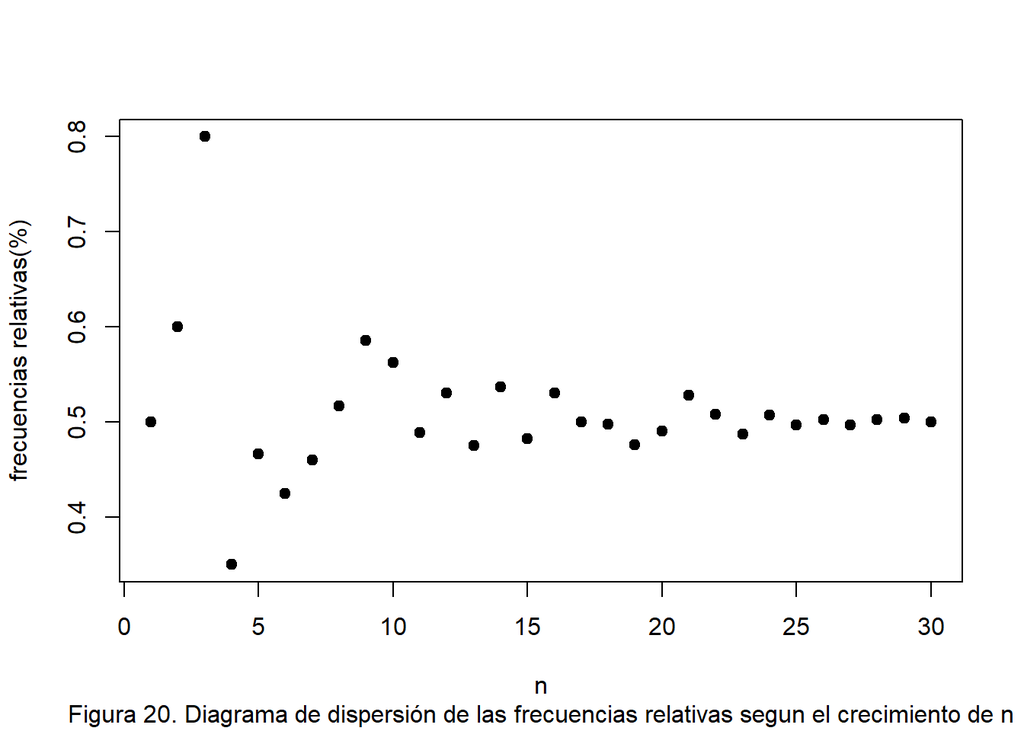

    ```r
       plot(1:30,
       f_n,
       pch=19,
       ylab="frecuencias relativas(%)",
       xlab ="n",
       #ylim= c(0,1),
       sub="Figura 20. Diagrama de dispersión de las frecuencias relativas segun el crecimiento de n")
    ```

    3. Trazar una línea paralela al eje X que corte en el eje Y en el valor de la probabilidad de caer cara P(C).

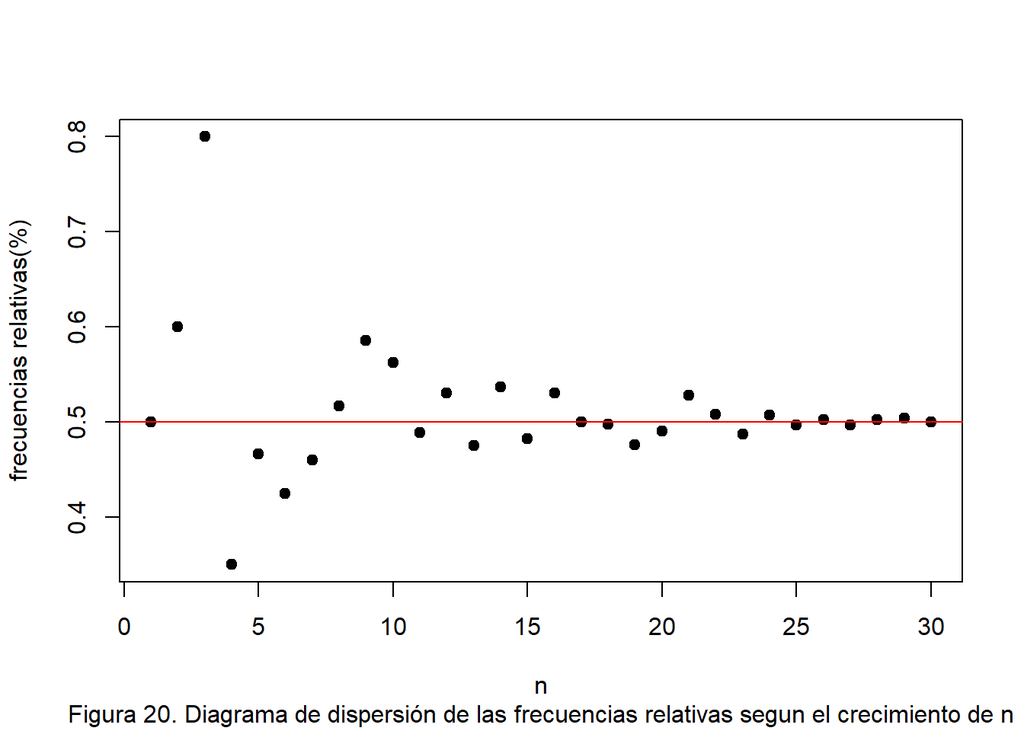

    ```r
       plot(1:30,
       f_n,
       pch=19,
       ylab="frecuencias relativas(%)",
       xlab ="n",
       #ylim= c(0,1),
       sub="Figura 20. Diagrama de dispersión de las frecuencias relativas segun el crecimiento de n")
       lines(-1:32,
      rep(1/2,34),
      col="red",
      lwd=1)
    ```

    4. Interpretar los resultados que relacionan a f<sub>n</sub>(C) y P(C) conforme aumenta el valor de n.